# Reproducible Research: Peer Assessment 1

## Loading and preprocessing the data

Load libraries and delete variables

```r
library(plyr)
library(dplyr)
library(data.table)
library(chron)
library(lattice)
# library(lubridate)
rm(list=ls())
```

Create data directory (if it does not exist previously) and unzip the .zip data file in the “data” directory.

```r
# Create data folder if it does not exist
if (!file.exists("data")) {
        dir.create("data")
}
# Unzip file in "data" directory
unzip(zipfile = "activity.zip", exdir = "./data")
```

The data frame is created with fread and the data structure and type of each variable is checked.

```r
# Create a "Data Frame" with "fread"
df <- fread("./data/activity.csv")
head(df)
```

```
##    steps       date interval
## 1:    NA 2012-10-01        0
## 2:    NA 2012-10-01        5
## 3:    NA 2012-10-01       10
## 4:    NA 2012-10-01       15
## 5:    NA 2012-10-01       20
## 6:    NA 2012-10-01       25
```

```r
str(df)
```

```
## Classes 'data.table' and 'data.frame':   17568 obs. of  3 variables:
##  $ steps   : int  NA NA NA NA NA NA NA NA NA NA ...
##  $ date    : IDate, format: "2012-10-01" "2012-10-01" ...
##  $ interval: int  0 5 10 15 20 25 30 35 40 45 ...
##  - attr(*, ".internal.selfref")=<externalptr>
```

```r
summary(df)
```

```
##      steps             date               interval
##  Min.   :  0.00   Min.   :2012-10-01   Min.   :   0.0
##  1st Qu.:  0.00   1st Qu.:2012-10-16   1st Qu.: 588.8
##  Median :  0.00   Median :2012-10-31   Median :1177.5
##  Mean   : 37.38   Mean   :2012-10-31   Mean   :1177.5
##  3rd Qu.: 12.00   3rd Qu.:2012-11-15   3rd Qu.:1766.2
##  Max.   :806.00   Max.   :2012-11-30   Max.   :2355.0
##  NA's   :2304
```

## What is mean total number of steps taken per day?

### *Calculate the total number of steps taken per day*

```r
# For this part of the assignment, you can ignore the missing values in the dataset.
# Note the use of the '.' function to allow date be used without quoting
df_day <- ddply(df, .(date), summarize,
                sum = sum(steps, na.rm = TRUE),
                mean = mean(steps, na.rm = TRUE),
                median = median(steps, na.rm = TRUE)
                )

df_day
```

```
##          date   sum       mean median
## 1  2012-10-01     0        NaN     NA
## 2  2012-10-02   126  0.4375000      0
## 3  2012-10-03 11352 39.4166667      0
## 4  2012-10-04 12116 42.0694444      0
## 5  2012-10-05 13294 46.1597222      0
## 6  2012-10-06 15420 53.5416667      0
## 7  2012-10-07 11015 38.2465278      0
## 8  2012-10-08     0        NaN     NA
## 9  2012-10-09 12811 44.4826389      0
## 10 2012-10-10  9900 34.3750000      0
## 11 2012-10-11 10304 35.7777778      0
## 12 2012-10-12 17382 60.3541667      0
## 13 2012-10-13 12426 43.1458333      0
## 14 2012-10-14 15098 52.4236111      0
```

[output cut: 47 more lines]

### *Make a histogram of the total number of steps taken each day*

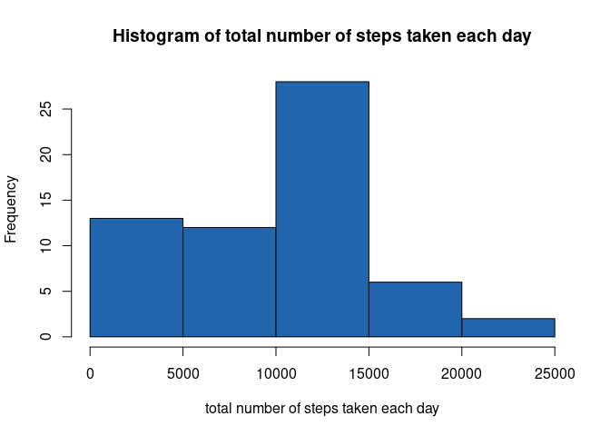

```r
hist(df_day$sum,
     main="Histogram of total number of steps taken each day",
     xlab = "total number of steps taken each day",
     col="#2166AC")
```

```r
dev.copy(png, file = "figure/hist_steps_day.png")
```

```r
dev.off()
```

```r
# Calculate and report the mean and median of the total number
# of steps taken per day
mean_step_day <- mean(df$steps, na.rm = TRUE)
median_step_day <- median(df$steps, na.rm = TRUE)
```

## What is the average daily activity pattern?

### Make plot of the 5-minute interval *vs* average number of steps taken

Calculation of average number of steps per 5-minute interval per day

```r
# Make a time series plot type = "l" of the 5-minute interval (x-axis) and
# the average number of steps taken, averaged across all days (y-axis)

df_minute <- ddply(df, .(interval), summarize,
                mean = mean(steps, na.rm = TRUE),
                )

head(df_minute)
```

```
##   interval      mean
## 1        0 1.7169811
## 2        5 0.3396226
## 3       10 0.1320755
## 4       15 0.1509434
## 5       20 0.0754717
## 6       25 2.0943396
```

Time series plot type = “l” of the 5-minute interval (x-axis) and the average number of steps taken, averaged across all days (y-axis)

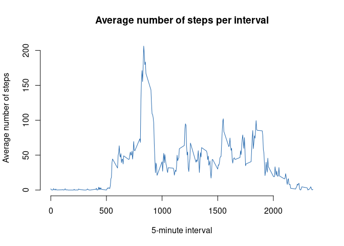

```r
plot(x=df_minute$interval,
     y=df_minute$mean,
     type="l",
     main="Average number of steps per interval",
     xlab = "5-minute interval",
     ylab = "Average number of steps",
     col="#2166AC",
     frame.plot = FALSE)
```

```r
dev.copy(png, file = "figure/plot_line_step_interval.png")
```

```r
dev.off()
```